# Serious(ly,) Money for Thoughts

# The Opportunity Cost of Reduced Capital Markets Participation - A Brief Analysis

The Portuguese government’s recent changes to Treasury Certificates (1) have ignited a fierce and politically motivated debate about their purpose, consequences, and vested interests. Nevertheless, this public discourse is highly counterproductive, diverting our attention from far more important and pressing issues. Portugal ranks last in financial literacy of the general public among its Eurozone counterparts (2) and despite the advancement of new technologies and business models that have broadly increased access to capital markets participation through low-cost or no-fees brokerage services, internet-native and mobile platforms or fractional shares, only 9.22% of Portuguese households are invested in capital markets (3) (more recent studies found higher shares of participation – 52% – through the inclusion of government savings products (4)). From 1980 until 2020, households have had an average of 54.81% of their financial assets in cash and deposits (5). Despite a decreasing trend, 2021 46.54% share of cash and equivalents is considerably high.

To shed light on the opportunity cost of the poor financial literacy of the Portuguese population and the resulting reduced capital markets participation, I calculated the missed potential gains from market participation between 2002 and 2021. Assuming a 20% cash balance as adequate and using Bank of Portugal Household Wealth Long Series data (5), a yearly household portfolio excess cash was computed. This excess cash was assumed to be invested in a traditional 60/40 portfolio throughout this period. Portfolio components were the MSCI World net total return and Bloomberg Global Aggregate total return euro-denominated indexes to keep it diversified and coherent with the Portuguese households’ conservative approach to investment (4). Since annual returns were reinvested in the following years, and to keep the share of cash constant, only 80% of accumulated returns were assumed to be reinvested along with the respective year portfolio excess cash. All R code used to produce the results presented here is available on GitHub at [Financial Literacy Opportunity Cost Repository](https://github.com/JPRRamalho/Financial_Literacy_Opportunity_Cost).

During these 20 years, only between 2005 and 2008 did cash balances drop below 40% of households’ total financial assets, with an increasing trend ever since (Figure 1A). Over the same period, the 60/40 portfolio yielded an annualized total return of 6.30%. The selected portfolio seems to have had adequate diversification showing only three years of negative returns (2002, 2008 and 2018) (Figure 1B). Figure 1C shows the missed potential cumulative returns over the years. Following the proposed allocation, the Portuguese population missed €181.89 billion in returns due to its suboptimal capital markets participation. The true magnitude of this number is better put into perspective by establishing some simple yet illuminating comparisons: €181.89 billion amounts to more than ten times the €16.6 billion of the Recovery and Resilience Facility earmarked for Portugal, 7.8 times the €23.18 billion Social Security Financial Stabilization Fund, and more than 67% of Portugal gross debt (2021 numbers) (6,7).

## Figure 1

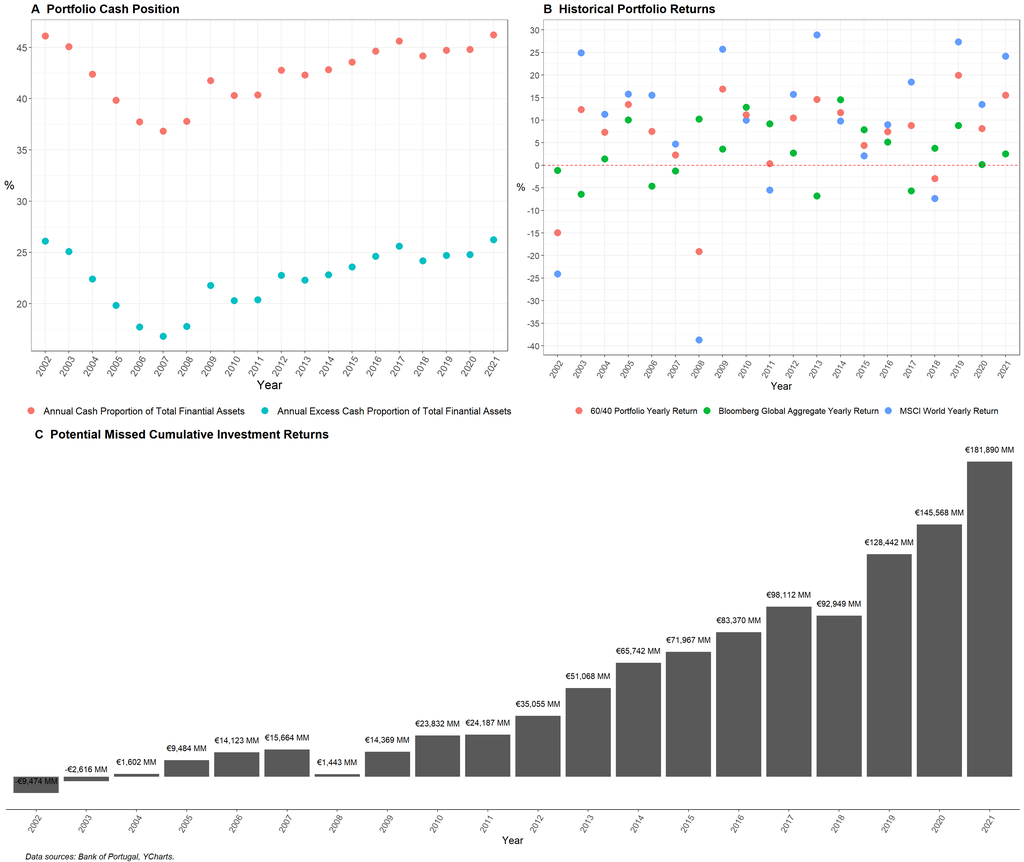

Despite using net total return indexes to account for non-appreciation returns, country taxes on capital gains were ignored. Other limitations to this work, such as the assumption of no additional wealth transfers to real estate assets or no returns on cash and deposits, should also be considered. The difficulty in assessing yearly returns on a bond portfolio of national treasuries (8) made it unfeasible to use a 60/40 national securities portfolio in this analysis.

Although ignoring the crucial issue of wealth distribution and equity, it seems evident that poor financial literacy bears a very high hidden opportunity cost, which adds to other unmeasured consequences of many other suboptimal personal financial decisions. In fact, we could say that the lack of financial literacy cost Portuguese households at least €181.89 billion in the 20-year period of 2002-2021 (€17,454.03 per resident).

While advances have happened, a complete democratization of access to capital markets and wealth building will remain elusive and uneven, worsening the wealth gap as long as financial literacy is not a priority.

## References

1. Portaria n.o 149-A/2023 [Internet]. 149-A Jun 2, 2023. Available [here](https://diariodarepublica.pt/dr/detalhe/portaria/149-a-2023-213940447).
2. Gardt M, Angino S, Mee S, Glöckler G. ECB Communication with the wider public. 2022 Jan 12 [cited 2023 Jun 16]; Available [here](https://www.ecb.europa.eu/pub/economic-bulletin/articles/2022/html/ecb.ebart202108_02~5c1e5a116d.en.html).
3. CMVM - O Perfil do Investidor Particular Português [Internet]. [cited 2023 Jun 16]. Available [here](https://www.cmvm.pt/pt/EstatisticasEstudosEPublicacoes/Estudos/Pages/O%20Perfil%20do%20Investidor%20Particular%20Portugu%C3%AAs.aspx?v=).
4. Resultados do Inquérito Online ao Investidor 2018 [Internet]. CMVM; 2019 Apr [cited 2023 Jun 16]. Available [here](https://www.cmvm.pt/pt/EstatisticasEstudosEPublicacoes/Estudos/Documents/Resultados%20Inquerito%20Online%20Perfil%20Investidor_2019.pdf).
5. Séries para a economia portuguesa – Património dos particulares [Internet]. BPstat. [cited 2023 Jun 16]. Available [here](https://bpstat.bportugal.pt/conteudos/quadros/655).
6. FUNDO DE ESTABILIZAÇÃO FINANCEIRA DA SEGURANÇA SOCIAL - RELATÓRIO E CONTAS 2021 [Internet]. Porto: INSTITUTO DE GESTÃO DE FUNDOS DE CAPITALIZAÇÃO DA SEGURANÇA SOCIAL, I.P.; 2022 Mar [cited 2023 Jun 20]. Available [here](https://www.seg-social.pt/documents/10152/438902/Rel_Ativ_FEFSS_2021/d21f2b3d-a77a-489d-a266-d37080ae7112).
7. General Government: gross debt [Internet]. [cited 2023 Jun 20]. Available [here](https://www.pordata.pt/en/portugal/general+government+gross+debt-2783).
8. Janeiro F. The Portuguese Bond Index: A measure for bond portfolio performance. PORTUGUESE TREASURY AND DEBT MANAGEMENT AGENCY [Internet]. 2017 Sep 20 [cited 2023 Jun 20]; Available [here](https://www.igcp.pt/fotos/editor2/2017/Estudos/The_Portuguese_Bond_Index_A_measure_for_bond_portfolio_performance.pdf).

## Package References

```
##   - Csárdi G, Torvalds L (2022). _parsedate: Recognize and Parse Dates in Various Formats, Including All ISO 8601 Formats_. R package version 1.3.1, <https://CRAN.R-project.org/package=parsedate>.
##   - Dancho M, Vaughan D (2023). _tidyquant: Tidy Quantitative Financial Analysis_. R package version 1.0.7, <https://CRAN.R-project.org/package=tidyquant>.
##   - Firke S (2023). _janitor: Simple Tools for Examining and Cleaning Dirty Data_. R package version 2.2.0, <https://CRAN.R-project.org/package=janitor>.
##   - Grolemund G, Wickham H (2011). "Dates and Times Made Easy with lubridate." _Journal of Statistical Software_, *40*(3), 1-25. <https://www.jstatsoft.org/v40/i03/>.
##   - Kassambara A (2023). _ggpubr: 'ggplot2' Based Publication Ready Plots_. R package version 0.6.0, <https://CRAN.R-project.org/package=ggpubr>.
##   - Makowski D, Lüdecke D, Patil I, Thériault R, Ben-Shachar M, Wiernik B (2023). "Automated Results Reporting as a Practical Tool to Improve Reproducibility and Methodological Best Practices Adoption." _CRAN_. <https://easystats.github.io/report/>.
##   - Müller K, Wickham H (2023). _tibble: Simple Data Frames_. R package version 3.2.1, <https://CRAN.R-project.org/package=tibble>.
##   - Peterson BG, Carl P (2020). _PerformanceAnalytics: Econometric Tools for Performance and Risk Analysis_. R package version 2.0.4, <https://CRAN.R-project.org/package=PerformanceAnalytics>.
##   - R Core Team (2023). _R: A Language and Environment for Statistical Computing_. R Foundation for Statistical Computing, Vienna, Austria. <https://www.R-project.org/>.
##   - Ryan JA, Ulrich JM (2023). _quantmod: Quantitative Financial Modelling Framework_. R package version 0.4.23, <https://CRAN.R-project.org/package=quantmod>.
##   - Ryan JA, Ulrich JM (2023). _xts: eXtensible Time Series_. R package version 0.13.0, <https://CRAN.R-project.org/package=xts>.
##   - Ulrich J (2021). _TTR: Technical Trading Rules_. R package version 0.24.3, <https://CRAN.R-project.org/package=TTR>.
##   - Wickham H (2016). _ggplot2: Elegant Graphics for Data Analysis_. Springer-Verlag New York. ISBN 978-3-319-24277-4, <https://ggplot2.tidyverse.org>.
##   - Wickham H (2022). _stringr: Simple, Consistent Wrappers for Common String Operations_. R package version 1.5.0, <https://CRAN.R-project.org/package=stringr>.
##   - Wickham H (2023). _forcats: Tools for Working with Categorical Variables (Factors)_. R package version 1.0.0, <https://CRAN.R-project.org/package=forcats>.
##   - Wickham H, Averick M, Bryan J, Chang W, McGowan LD, François R, Grolemund G, Hayes A, Henry L, Hester J, Kuhn M, Pedersen TL, Miller E, Bache SM, Müller K, Ooms J, Robinson D, Seidel DP, Spinu V, Takahashi K, Vaughan D, Wilke C, Woo K, Yutani H (2019). "Welcome to the tidyverse." _Journal of …
##   - Wickham H, François R, Henry L, Müller K, Vaughan D (2023). _dplyr: A Grammar of Data Manipulation_. R package version 1.1.1, <https://CRAN.R-project.org/package=dplyr>.
##   - Wickham H, Henry L (2023). _purrr: Functional Programming Tools_. R package version 1.0.1, <https://CRAN.R-project.org/package=purrr>.
##   - Wickham H, Hester J, Bryan J (2023). _readr: Read Rectangular Text Data_. R package version 2.1.4, <https://CRAN.R-project.org/package=readr>.
##   - Wickham H, Seidel D (2022). _scales: Scale Functions for Visualization_. R package version 1.2.1, <https://CRAN.R-project.org/package=scales>.
##   - Wickham H, Vaughan D, Girlich M (2023). _tidyr: Tidy Messy Data_. R package version 1.3.0, <https://CRAN.R-project.org/package=tidyr>.
##   - Zeileis A, Grothendieck G (2005). "zoo: S3 Infrastructure for Regular and Irregular Time Series." _Journal of Statistical Software_, *14*(6), 1-27. doi:10.18637/jss.v014.i06 <https://doi.org/10.18637/jss.v014.i06>.
```

[^1]: ISCTE Business School, NOVA National School of Public Health, jose_pedro_ramalho@iscte-iul.pt